# K-fold Factor Analysis - Example Sim

September 01, 2022

# Overview

**# of folds:** 4

**# of variables:** 20

**# of observations:** 900

**Maximum # of factors:**

- Allowed - 5
- Extracted - 3

**Estimation:** ML

**Missing Data:** listwise

# Model Summary

**Fit across folds by factor model**

| model | df.scaled | chisq.scaled mean | chisq.scaled range | cfi.scaled mean | cfi.scaled range | rmsea.scaled mean | rmsea.scaled range |
| --- | --- | --- | --- | --- | --- | --- | --- |
| 1-factor | 46.07182 | 244.18 | 227.42 - 260.26 | 0.12 | 0.00 - 0.20 | 0.14 | 0.13 - 0.15 |
| 2-factor | 48.34143 | 121.98 | 121.98 - 121.98 | 0.63 | 0.63 - 0.63 | 0.08 | 0.08 - 0.08 |
| 3-factor | 81.95118 | 82.73 | 70.74 - 92.37 | 0.98 | 0.96 - 1.00 | 0.01 | 0.00 - 0.02 |
| custom2f | 53.98938 | 199.03 | 186.83 - 219.97 | 0.33 | 0.16 - 0.44 | 0.11 | 0.10 - 0.12 |

**Count of folds out of 4 with flagged problems**

| model | mode structure | improper solution | heywood item | low loading | high factor correlation | low scale reliability |
| --- | --- | --- | --- | --- | --- | --- |
| 1-factor | 4 | 0 | 0 | 4 |  | 4 |
| 2-factor | 1 | 0 | 0 | 1 | 0 | 0 |
| 3-factor | 4 | 0 | 0 | 2 | 0 | 0 |
| custom2f | 4 | 1 | 0 | 4 | 0 | 2 |

# Model Details

## 1-factor

**Factor Structure**

f1 =~ x1 + x2 + x3 + x4 + x5 + x6 + x7 + x8 + x9 + x10 + x11 + x12 + x13 + x14 + x15 + x16 + x17 + x18 + x19 + x20

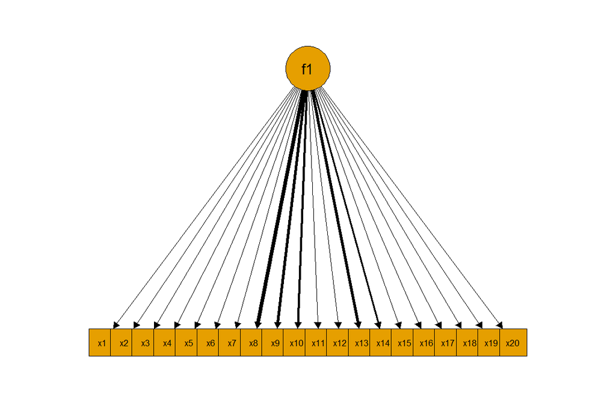

**Standardized Loading Across Folds**

| variable | mean | range | loading flag | heywood flag |
| --- | --- | --- | --- | --- |
| x1 | 0.56 | 0.18 - 0.69 | 1 | 0 |
| x2 | 0.64 | 0.21 - 0.82 | 1 | 0 |
| x3 | 0.27 | 0.11 - 0.40 | 3 | 0 |
| x4 | 0.58 | 0.20 - 0.72 | 1 | 0 |
| x5 | 0.49 | 0.14 - 0.66 | 1 | 0 |
| x6 | 0.65 | 0.21 - 0.83 | 1 | 0 |
| x7 | 0.27 | 0.13 - 0.34 | 2 | 0 |
| x8 | 0.40 | 0.24 - 0.82 | 3 | 0 |
| x9 | 0.39 | 0.22 - 0.76 | 3 | 0 |
| x10 | 0.30 | 0.13 - 0.71 | 3 | 0 |
| x11 | 0.24 | 0.09 - 0.48 | 3 | 0 |
| x12 | 0.26 | 0.11 - 0.57 | 3 | 0 |
| x13 | 0.37 | 0.20 - 0.75 | 3 | 0 |
| x14 | 0.36 | 0.18 - 0.67 | 2 | 0 |
| x15 | 0.14 | 0.06 - 0.25 | 4 | 0 |
| x16 | 0.12 | -0.01 - 0.23 | 4 | 0 |
| x17 | 0.22 | 0.03 - 0.33 | 3 | 0 |
| x18 | 0.10 | 0.03 - 0.18 | 4 | 0 |
| x19 | 0.19 | 0.09 - 0.30 | 3 | 0 |
| x20 | 0.10 | 0.05 - 0.14 | 4 | 0 |

Note: loadings flagged when < 0.3 in a fold. ‘heywood flag’ is the number of folds the variable’s estimated residual variance was negative

**Scale Reliability Across Folds**

| factor | omega_h mean | omega_h range | omega_h flag | alpha mean | alpha range | alpha flag |
| --- | --- | --- | --- | --- | --- | --- |
| f1 | 0.79 | 0.77 - 0.82 | 0 | 0.56 | 0.51 - 0.60 | 4 |

Note: ‘flag’ is the number of folds the scale had a reliability < 0.6

## 2-factor

**Factor Structure**

f1 =~ x1 + x2 + x3 + x4 + x5 + x6 + x7 + x16 + x17

f2 =~ x8 + x9 + x10 + x11 + x12 + x13 + x14 + x15 + x18 + x19 + x20

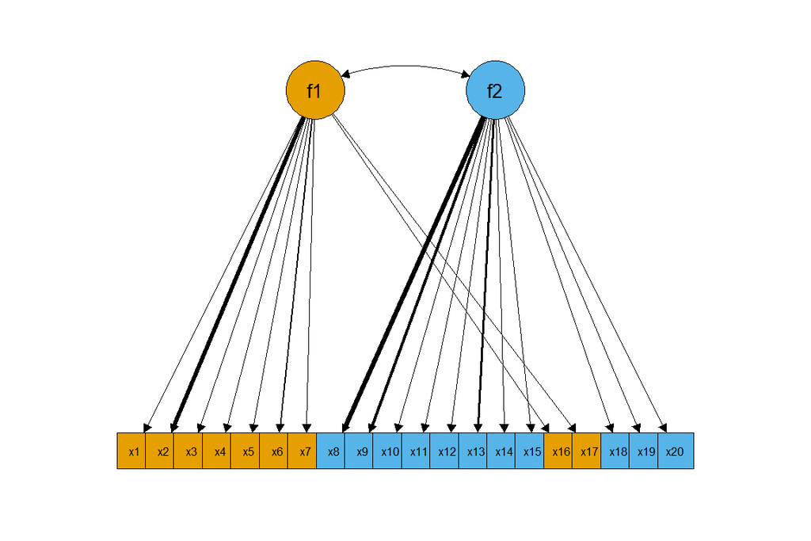

**Standardized Loading Across Folds**

| variable | mean | range | loading flag | heywood flag |
| --- | --- | --- | --- | --- |
| x1 | 0.74 | 0.74 - 0.74 | 0 | 0 |
| x2 | 0.81 | 0.81 - 0.81 | 0 | 0 |
| x3 | 0.27 | 0.27 - 0.27 | 1 | 0 |
| x4 | 0.69 | 0.69 - 0.69 | 0 | 0 |
| x5 | 0.55 | 0.55 - 0.55 | 0 | 0 |
| x6 | 0.76 | 0.76 - 0.76 | 0 | 0 |
| x7 | 0.43 | 0.43 - 0.43 | 0 | 0 |
| x8 | 0.83 | 0.83 - 0.83 | 0 | 0 |
| x9 | 0.78 | 0.78 - 0.78 | 0 | 0 |
| x10 | 0.71 | 0.71 - 0.71 | 0 | 0 |
| x11 | 0.49 | 0.49 - 0.49 | 0 | 0 |
| x12 | 0.57 | 0.57 - 0.57 | 0 | 0 |
| x13 | 0.76 | 0.76 - 0.76 | 0 | 0 |
| x14 | 0.67 | 0.67 - 0.67 | 0 | 0 |
| x15 | 0.19 | 0.19 - 0.19 | 1 | 0 |
| x16 | 0.19 | 0.19 - 0.19 | 1 | 0 |
| x17 | 0.25 | 0.25 - 0.25 | 1 | 0 |
| x18 | 0.09 | 0.09 - 0.09 | 1 | 0 |
| x19 | 0.25 | 0.25 - 0.25 | 1 | 0 |
| x20 | 0.10 | 0.10 - 0.10 | 1 | 0 |

Note: loadings flagged when < 0.3 in a fold. ‘heywood flag’ is the number of folds the variable’s estimated residual variance was negative

**Mean Factor Correlations**

|  | f1 | f2 | flag |
| --- | --- | --- | --- |
| f1 | 1.00 |  | 0 |
| f2 | 0.18 | 1.00 | 0 |

Note: ‘flag’ is the number of folds the factor had a correlation > 0.9

**Scale Reliability Across Folds**

| factor | omega_h mean | omega_h range | omega_h flag | alpha mean | alpha range | alpha flag |
| --- | --- | --- | --- | --- | --- | --- |
| f1 | 0.76 | 0.76 - 0.76 | 0 | 0.77 | 0.77 - 0.77 | 0 |
| f2 | 0.81 | 0.81 - 0.81 | 0 | 0.74 | 0.74 - 0.74 | 0 |

Note: ‘flag’ is the number of folds the scale had a reliability < 0.6

## 3-factor

**Factor Structure**

f1 =~ x1 + x2 + x3 + x4 + x5 + x6 + x7

f2 =~ x8 + x9 + x10 + x11 + x12 + x13 + x14

f3 =~ x15 + x16 + x17 + x18 + x19 + x20

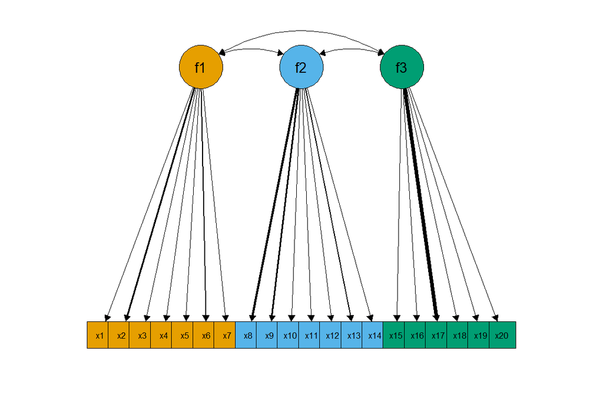

**Standardized Loading Across Folds**

| variable | mean | range | loading flag | heywood flag |
| --- | --- | --- | --- | --- |
| x1 | 0.70 | 0.67 - 0.74 | 0 | 0 |
| x2 | 0.81 | 0.77 - 0.83 | 0 | 0 |
| x3 | 0.31 | 0.26 - 0.40 | 2 | 0 |
| x4 | 0.70 | 0.67 - 0.73 | 0 | 0 |
| x5 | 0.61 | 0.55 - 0.66 | 0 | 0 |
| x6 | 0.81 | 0.76 - 0.85 | 0 | 0 |
| x7 | 0.35 | 0.28 - 0.43 | 1 | 0 |
| x8 | 0.79 | 0.73 - 0.84 | 0 | 0 |
| x9 | 0.74 | 0.70 - 0.78 | 0 | 0 |
| x10 | 0.61 | 0.55 - 0.71 | 0 | 0 |
| x11 | 0.46 | 0.40 - 0.49 | 0 | 0 |
| x12 | 0.51 | 0.43 - 0.57 | 0 | 0 |
| x13 | 0.71 | 0.67 - 0.76 | 0 | 0 |
| x14 | 0.64 | 0.60 - 0.67 | 0 | 0 |
| x15 | 0.62 | 0.56 - 0.71 | 0 | 0 |
| x16 | 0.48 | 0.44 - 0.54 | 0 | 0 |
| x17 | 0.91 | 0.87 - 0.93 | 0 | 0 |
| x18 | 0.44 | 0.39 - 0.49 | 0 | 0 |
| x19 | 0.71 | 0.66 - 0.78 | 0 | 0 |
| x20 | 0.49 | 0.46 - 0.56 | 0 | 0 |

Note: loadings flagged when < 0.3 in a fold. ‘heywood flag’ is the number of folds the variable’s estimated residual variance was negative

**Mean Factor Correlations**

|  | f1 | f2 | f3 | flag |
| --- | --- | --- | --- | --- |
| f1 | 1.00 |  |  | 0 |
| f2 | 0.20 | 1.00 |  | 0 |
| f3 | 0.17 | 0.16 | 1.00 | 0 |

Note: ‘flag’ is the number of folds the factor had a correlation > 0.9

**Scale Reliability Across Folds**

| factor | omega_h mean | omega_h range | omega_h flag | alpha mean | alpha range | alpha flag |
| --- | --- | --- | --- | --- | --- | --- |
| f1 | 0.80 | 0.79 - 0.82 | 0 | 0.81 | 0.79 - 0.83 | 0 |
| f2 | 0.82 | 0.81 - 0.86 | 0 | 0.83 | 0.81 - 0.87 | 0 |
| f3 | 0.78 | 0.76 - 0.79 | 0 | 0.79 | 0.76 - 0.81 | 0 |

Note: ‘flag’ is the number of folds the scale had a reliability < 0.6

## custom2f

**Factor Structure**

f1 =~ x1 + x2 + x3 + x4 + x5 + x6 + x7 + x8 + x9 + x10

f2 =~ x11 + x12 + x13 + x14 + x15 + x16 + x17 + x18 + x19 + x20

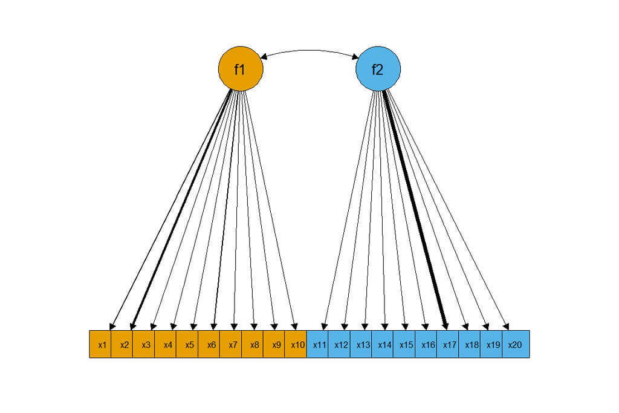

**Standardized Loading Across Folds**

| variable | mean | range | loading flag | heywood flag |
| --- | --- | --- | --- | --- |
| x1 | 0.70 | 0.67 - 0.73 | 0 | 0 |
| x2 | 0.81 | 0.77 - 0.83 | 0 | 0 |
| x3 | 0.31 | 0.26 - 0.40 | 2 | 0 |
| x4 | 0.70 | 0.67 - 0.73 | 0 | 0 |
| x5 | 0.60 | 0.55 - 0.66 | 0 | 0 |
| x6 | 0.81 | 0.76 - 0.85 | 0 | 0 |
| x7 | 0.35 | 0.28 - 0.43 | 1 | 0 |
| x8 | 0.19 | 0.17 - 0.21 | 4 | 0 |
| x9 | 0.18 | 0.13 - 0.23 | 4 | 0 |
| x10 | 0.12 | 0.06 - 0.18 | 4 | 0 |
| x11 | 0.06 | 0.02 - 0.14 | 4 | 0 |
| x12 | 0.15 | 0.07 - 0.19 | 4 | 0 |
| x13 | 0.13 | 0.08 - 0.26 | 4 | 0 |
| x14 | 0.13 | 0.06 - 0.25 | 4 | 0 |
| x15 | 0.62 | 0.56 - 0.71 | 0 | 0 |
| x16 | 0.48 | 0.44 - 0.54 | 0 | 0 |
| x17 | 0.90 | 0.87 - 0.93 | 0 | 0 |
| x18 | 0.45 | 0.39 - 0.49 | 0 | 0 |
| x19 | 0.71 | 0.66 - 0.79 | 0 | 0 |
| x20 | 0.49 | 0.46 - 0.56 | 0 | 0 |

Note: loadings flagged when < 0.3 in a fold. ‘heywood flag’ is the number of folds the variable’s estimated residual variance was negative

**Mean Factor Correlations**

|  | f1 | f2 | flag |
| --- | --- | --- | --- |
| f1 | 1.00 |  | 0 |
| f2 | 0.18 | 1.00 | 0 |

Note: ‘flag’ is the number of folds the factor had a correlation > 0.9

**Scale Reliability Across Folds**

| factor | omega_h mean | omega_h range | omega_h flag | alpha mean | alpha range | alpha flag |
| --- | --- | --- | --- | --- | --- | --- |
| f1 | 0.76 | 0.75 - 0.77 | 0 | 0.71 | 0.67 - 0.72 | 0 |
| f2 | 0.71 | 0.69 - 0.75 | 0 | 0.62 | 0.60 - 0.67 | 2 |

Note: ‘flag’ is the number of folds the scale had a reliability < 0.6

# Appendix

## Within Fold Model Fit

| fold | 1-factor chisq.scaled | 1-factor df.scaled | 1-factor cfi.scaled | 1-factor rmsea.scaled | 2-factor chisq.scaled | 2-factor df.scaled | 2-factor cfi.scaled | 2-factor rmsea.scaled | 3-factor chisq.scaled | 3-factor df.scaled | 3-factor cfi.scaled | 3-factor rmsea.scaled | custom2f chisq.scaled | custom2f df.scaled | custom2f cfi.scaled | custom2f rmsea.scaled |
| --- | --- | --- | --- | --- | --- | --- | --- | --- | --- | --- | --- | --- | --- | --- | --- | --- |
| 1 | 260.18 | 44.07 | 0.00 | 0.15 | 121.98 | 48.34 | 0.63 | 0.08 | 92.37 | 84.80 | 0.96 | 0.02 | 219.97 | 48.40 | 0.16 | 0.12 |
| 2 | 260.26 | 51.30 | 0.10 | 0.13 |  |  |  |  | 80.05 | 80.41 | 1.00 | 0.00 | 186.83 | 56.60 | 0.44 | 0.10 |
| 3 | 228.85 | 45.83 | 0.20 | 0.13 |  |  |  |  | 70.74 | 81.57 | 1.00 | 0.00 |  |  |  |  |
| 4 | 227.42 | 43.09 | 0.17 | 0.14 |  |  |  |  | 87.76 | 81.02 | 0.97 | 0.02 | 190.28 | 56.96 | 0.40 | 0.10 |
| Mean | 244.18 | 46.07 | 0.12 | 0.14 | 121.98 | 48.34 | 0.63 | 0.08 | 82.73 | 81.95 | 0.98 | 0.01 | 199.03 | 53.99 | 0.33 | 0.11 |

## All EFA Structures

### Factors: 1

**Factor Structure Option 1**

**In Folds: 1, 2, 3, 4**

f1 =~ x1 + x2 + x3 + x4 + x5 + x6 + x7 + x8 + x9 + x10 + x11 + x12 + x13 + x14 + x15 + x16 + x17 + x18 + x19 + x20

### Factors: 2

**Factor Structure Option 1**

**In Folds: 1**

f1 =~ x1 + x2 + x3 + x4 + x5 + x6 + x7 + x16 + x17

f2 =~ x8 + x9 + x10 + x11 + x12 + x13 + x14 + x15 + x18 + x19 + x20

**Factor Structure Option 2**

**In Folds: 2**

f1 =~ x1 + x2 + x3 + x4 + x5 + x6 + x7 + x15 + x16 + x17 + x18 + x20

f2 =~ x8 + x9 + x10 + x11 + x12 + x13 + x14 + x19

**Factor Structure Option 3**

**In Folds: 3**

f1 =~ x1 + x2 + x3 + x4 + x5 + x6 + x7 + x8 + x9 + x10 + x12 + x13 + x14

f2 =~ x11 + x15 + x16 + x17 + x18 + x19 + x20

**Factor Structure Option 4**

**In Folds: 4**

f1 =~ x1 + x2 + x3 + x4 + x5 + x6 + x7 + x8 + x9 + x11 + x13 + x14

f2 =~ x10 + x12 + x15 + x16 + x17 + x18 + x19 + x20

### Factors: 3

**Factor Structure Option 1**

**In Folds: 1, 2, 3, 4**

f1 =~ x1 + x2 + x3 + x4 + x5 + x6 + x7

f2 =~ x8 + x9 + x10 + x11 + x12 + x13 + x14

f3 =~ x15 + x16 + x17 + x18 + x19 + x20

### Factors: 4

**Factor Structure Option 1**

**In Folds: 1, 2, 3, 4**

Structure contained single item factor

### Factors: 5

**Factor Structure Option 1**

**In Folds: 1, 2, 3, 4**

Structure contained single item factor